# Weather Impact on NYC Flight Delays

Analysis of nycflights13 Dataset

Author

Generated by Databot

Published

November 4, 2025

```r
library(nycflights13)
```

**Note**

This report was generated using artificial intelligence (Claude from Anthropic) under general human direction. At the time of generation, the contents have not been comprehensively reviewed by a human analyst.

## Introduction

This report analyzes the `nycflights13` package, which contains detailed information about all 336,776 flights that departed from New York City airports (JFK, LGA, and EWR) in 2013.

The package includes five interconnected datasets:

- **flights**: Detailed flight information including times, delays, and routes
- **weather**: Hourly weather data at NYC airports
- **airlines**: Airline carrier codes and names
- **airports**: Airport metadata including location and timezone
- **planes**: Aircraft metadata including manufacturer and model

Our primary focus is on understanding **how weather conditions affect flight delays**, which has important implications for travelers, airlines, and airport operations.

## Data Exploration

```r
library(tidyverse)
library(nycflights13)
```

### Overview of the Flights Dataset

```r
# Examine the structure
glimpse(flights)
```

```
Rows: 336,776
Columns: 19
$ year           <int> 2013, 2013, 2013, 2013, 2013, 2013, 2013, 2013, 2013, 2…
$ month          <int> 1, 1, 1, 1, 1, 1, 1, 1, 1, 1, 1, 1, 1, 1, 1, 1, 1, 1, 1…
$ day            <int> 1, 1, 1, 1, 1, 1, 1, 1, 1, 1, 1, 1, 1, 1, 1, 1, 1, 1, 1…
$ dep_time       <int> 517, 533, 542, 544, 554, 554, 555, 557, 557, 558, 558, …
$ sched_dep_time <int> 515, 529, 540, 545, 600, 558, 600, 600, 600, 600, 600, …
$ dep_delay      <dbl> 2, 4, 2, -1, -6, -4, -5, -3, -3, -2, -2, -2, -2, -2, -1…
$ arr_time       <int> 830, 850, 923, 1004, 812, 740, 913, 709, 838, 753, 849,…
$ sched_arr_time <int> 819, 830, 850, 1022, 837, 728, 854, 723, 846, 745, 851,…
$ arr_delay      <dbl> 11, 20, 33, -18, -25, 12, 19, -14, -8, 8, -2, -3, 7, -1…
$ carrier        <chr> "UA", "UA", "AA", "B6", "DL", "UA", "B6", "EV", "B6", "…
$ flight         <int> 1545, 1714, 1141, 725, 461, 1696, 507, 5708, 79, 301, 4…
$ tailnum        <chr> "N14228", "N24211", "N619AA", "N804JB", "N668DN", "N394…
$ origin         <chr> "EWR", "LGA", "JFK", "JFK", "LGA", "EWR", "EWR", "LGA",…
$ dest           <chr> "IAH", "IAH", "MIA", "BQN", "ATL", "ORD", "FLL", "IAD",…
$ air_time       <dbl> 227, 227, 160, 183, 116, 150, 158, 53, 140, 138, 149, 1…
$ distance       <dbl> 1400, 1416, 1089, 1576, 762, 719, 1065, 229, 944, 733, …
$ hour           <dbl> 5, 5, 5, 5, 6, 5, 6, 6, 6, 6, 6, 6, 6, 6, 6, 5, 6, 6, 6…
$ minute         <dbl> 15, 29, 40, 45, 0, 58, 0, 0, 0, 0, 0, 0, 0, 0, 0, 59, 0…
$ time_hour      <dttm> 2013-01-01 05:00:00, 2013-01-01 05:00:00, 2013-01-01 0…
```

The flights dataset contains 336,776 observations with 19 variables covering:

- **Temporal data**: year, month, day, departure/arrival times
- **Delay information**: departure and arrival delays in minutes
- **Flight details**: carrier, flight number, tail number
- **Route information**: origin airport, destination, distance
- **Duration**: actual air time

### Summary Statistics

```r
summary(flights)
```

```
      year          month             day           dep_time    sched_dep_time
 Min.   :2013   Min.   : 1.000   Min.   : 1.00   Min.   :   1   Min.   : 106
 1st Qu.:2013   1st Qu.: 4.000   1st Qu.: 8.00   1st Qu.: 907   1st Qu.: 906
 Median :2013   Median : 7.000   Median :16.00   Median :1401   Median :1359
 Mean   :2013   Mean   : 6.549   Mean   :15.71   Mean   :1349   Mean   :1344
 3rd Qu.:2013   3rd Qu.:10.000   3rd Qu.:23.00   3rd Qu.:1744   3rd Qu.:1729
 Max.   :2013   Max.   :12.000   Max.   :31.00   Max.   :2400   Max.   :2359
                                                 NA's   :8255
   dep_delay          arr_time    sched_arr_time   arr_delay
 Min.   : -43.00   Min.   :   1   Min.   :   1   Min.   : -86.000
 1st Qu.:  -5.00   1st Qu.:1104   1st Qu.:1124   1st Qu.: -17.000
 Median :  -2.00   Median :1535   Median :1556   Median :  -5.000
 Mean   :  12.64   Mean   :1502   Mean   :1536   Mean   :   6.895
 3rd Qu.:  11.00   3rd Qu.:1940   3rd Qu.:1945   3rd Qu.:  14.000
 Max.   :1301.00   Max.   :2400   Max.   :2359   Max.   :1272.000
 NA's   :8255      NA's   :8713                  NA's   :9430
   carrier              flight       tailnum             origin
 Length:336776      Min.   :   1   Length:336776      Length:336776
 Class :character   1st Qu.: 553   Class :character   Class :character
 Mode  :character   Median :1496   Mode  :character   Mode  :character
                    Mean   :1972
                    3rd Qu.:3465
                    Max.   :8500

     dest              air_time        distance         hour
 Length:336776      Min.   : 20.0   Min.   :  17   Min.   : 1.00
 Class :character   1st Qu.: 82.0   1st Qu.: 502   1st Qu.: 9.00
 Mode  :character   Median :129.0   Median : 872   Median :13.00
                    Mean   :150.7   Mean   :1040   Mean   :13.18
                    3rd Qu.:192.0   3rd Qu.:1389   3rd Qu.:17.00
                    Max.   :695.0   Max.   :4983   Max.   :23.00
                    NA's   :9430
     minute        time_hour
 Min.   : 0.00   Min.   :2013-01-01 05:00:00.00
 1st Qu.: 8.00   1st Qu.:2013-04-04 13:00:00.00
 Median :29.00   Median :2013-07-03 10:00:00.00
 Mean   :26.23   Mean   :2013-07-03 05:22:54.64
 3rd Qu.:44.00   3rd Qu.:2013-10-01 07:00:00.00
 Max.   :59.00   Max.   :2013-12-31 23:00:00.00
```

**Key observations:**

- Average departure delay: 12.6 minutes
- Average arrival delay: 6.9 minutes
- Distance range: 17 to 4,983 miles
- Air time range: 20 to 695 minutes

### Missing Data Analysis

```r
# Count missing values by column
flights |>
  summarise(across(everything(), ~sum(is.na(.)))) |>
  pivot_longer(everything(), names_to = "variable", values_to = "missing_count") |>
  filter(missing_count > 0) |>
  arrange(desc(missing_count))
```

```
# A tibble: 6 × 2
  variable  missing_count
  <chr>             <int>
1 arr_delay          9430
2 air_time           9430
3 arr_time           8713
4 dep_time           8255
5 dep_delay          8255
6 tailnum            2512
```

The dataset has 8255 missing departure times and 8713 missing arrival times, likely representing cancelled flights.

### Related Tables

```r
# Airlines
head(airlines)
```

```
# A tibble: 6 × 2
  carrier name
  <chr>   <chr>
1 9E      Endeavor Air Inc.
2 AA      American Airlines Inc.
3 AS      Alaska Airlines Inc.
4 B6      JetBlue Airways
5 DL      Delta Air Lines Inc.
6 EV      ExpressJet Airlines Inc.
```

```r
# Airports
head(airports)
```

```
# A tibble: 6 × 8
  faa   name                             lat   lon   alt    tz dst   tzone
  <chr> <chr>                          <dbl> <dbl> <dbl> <dbl> <chr> <chr>
1 04G   Lansdowne Airport               41.1 -80.6  1044    -5 A     America/Ne…
2 06A   Moton Field Municipal Airport   32.5 -85.7   264    -6 A     America/Ch…
3 06C   Schaumburg Regional             42.0 -88.1   801    -6 A     America/Ch…
4 06N   Randall Airport                 41.4 -74.4   523    -5 A     America/Ne…
5 09J   Jekyll Island Airport           31.1 -81.4    11    -5 A     America/Ne…
6 0A9   Elizabethton Municipal Airport  36.4 -82.2  1593    -5 A     America/Ne…
```

```r
# Planes
head(planes)
```

```
# A tibble: 6 × 9
  tailnum  year type               manufacturer model engines seats speed engine
  <chr>   <int> <chr>              <chr>        <chr>   <int> <int> <int> <chr>
1 N10156   2004 Fixed wing multi … EMBRAER      EMB-…       2    55    NA Turbo…
2 N102UW   1998 Fixed wing multi … AIRBUS INDU… A320…       2   182    NA Turbo…
3 N103US   1999 Fixed wing multi … AIRBUS INDU… A320…       2   182    NA Turbo…
4 N104UW   1999 Fixed wing multi … AIRBUS INDU… A320…       2   182    NA Turbo…
5 N10575   2002 Fixed wing multi … EMBRAER      EMB-…       2    55    NA Turbo…
6 N105UW   1999 Fixed wing multi … AIRBUS INDU… A320…       2   182    NA Turbo…
```

```r
# Weather
head(weather)
```

```
# A tibble: 6 × 15
  origin  year month   day  hour  temp  dewp humid wind_dir wind_speed wind_gust
  <chr>  <int> <int> <int> <int> <dbl> <dbl> <dbl>    <dbl>      <dbl>     <dbl>
1 EWR     2013     1     1     1  39.0  26.1  59.4      270      10.4         NA
2 EWR     2013     1     1     2  39.0  27.0  61.6      250       8.06        NA
3 EWR     2013     1     1     3  39.0  28.0  64.4      240      11.5         NA
4 EWR     2013     1     1     4  39.9  28.0  62.2      250      12.7         NA
5 EWR     2013     1     1     5  39.0  28.0  64.4      260      12.7         NA
6 EWR     2013     1     1     6  37.9  28.0  67.2      240      11.5         NA
# ℹ 4 more variables: precip <dbl>, pressure <dbl>, visib <dbl>,
#   time_hour <dttm>
```

The weather table is particularly important for our analysis, containing hourly measurements of temperature, humidity, wind speed, precipitation, visibility, and atmospheric pressure.

## Weather Impact on Flight Delays

### Joining Flight and Weather Data

To analyze the relationship between weather and delays, we join the flights data with weather conditions at the time and location of each departure:

```r
# Join flights with weather data
flights_weather <- flights |>
  inner_join(weather, by = c("origin", "year", "month", "day", "hour", "time_hour"))

# Remove rows with missing delays
flights_weather_clean <- flights_weather |>
  filter(!is.na(dep_delay))

cat("Merged dataset has", format(nrow(flights_weather_clean), big.mark = ","), "observations\n")
```

```
Merged dataset has 326,993 observations
```

### Correlation Analysis

First, let’s examine the correlations between weather variables and departure delays:

```r
# Calculate correlations
weather_cor <- flights_weather_clean |>
  select(dep_delay, temp, dewp, humid, wind_speed, wind_gust, precip, pressure, visib) |>
  cor(use = "pairwise.complete.obs")

# Display correlations with departure delay
weather_cor[, "dep_delay"] |>
  sort(decreasing = TRUE) |>
  round(3)
```

```
 dep_delay      humid       dewp     precip       temp wind_speed  wind_gust
     1.000      0.117      0.102      0.090      0.061      0.047      0.041
     visib   pressure
    -0.094     -0.114
```

**Findings:**

- Weather correlations with delays are relatively weak (all under 0.12 in absolute value)
- **Humidity** shows the strongest positive correlation (0.117)
- **Pressure** and **visibility** show negative correlations (lower values = more delays)
- The weak correlations suggest weather is one of many factors affecting delays

### Precipitation Impact

Let’s categorize precipitation levels and examine their effect on delays:

```r
# Analyze delays by precipitation level
precip_summary <- flights_weather_clean |>
  mutate(precip_category = case_when(
    precip == 0 ~ "No precipitation",
    precip <= 0.1 ~ "Light (0-0.1 in)",
    precip <= 0.5 ~ "Moderate (0.1-0.5 in)",
    TRUE ~ "Heavy (>0.5 in)"
  )) |>
  group_by(precip_category) |>
  summarise(
    n_flights = n(),
    mean_delay = mean(dep_delay),
    median_delay = median(dep_delay),
    prop_delayed = mean(dep_delay > 0)
  ) |>
  arrange(desc(mean_delay))

precip_summary
```

```
# A tibble: 4 × 5
  precip_category       n_flights mean_delay median_delay prop_delayed
  <chr>                     <int>      <dbl>        <dbl>        <dbl>
1 Heavy (>0.5 in)             140       48.8           16        0.693
2 Moderate (0.1-0.5 in)      3600       40.6           11        0.646
3 Light (0-0.1 in)          17346       28.8            4        0.564
4 No precipitation         305907       11.4           -2        0.378
```

**Key insights:**

- Flights with **no precipitation** average only 11.4 minutes of delay
- **Heavy precipitation** (>0.5 inches) increases average delays to 48.8 minutes
- The proportion of delayed flights increases from 37.8% to 69.3% with heavy precipitation

#### Visualization: Delays by Precipitation

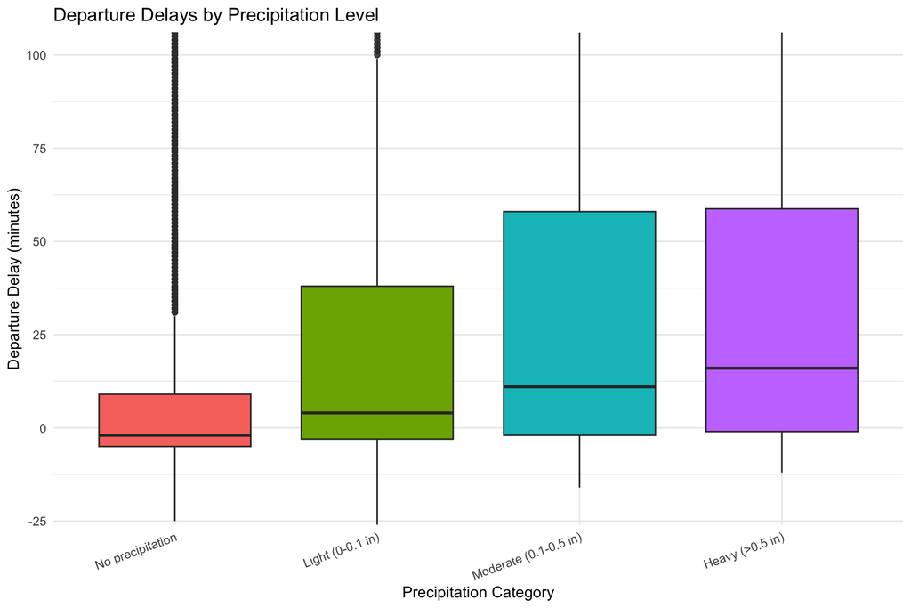

```r
# Create precipitation categories for visualization
flights_weather_plot <- flights_weather_clean |>
  mutate(precip_category = case_when(
    precip == 0 ~ "No precipitation",
    precip <= 0.1 ~ "Light (0-0.1 in)",
    precip <= 0.5 ~ "Moderate (0.1-0.5 in)",
    TRUE ~ "Heavy (>0.5 in)"
  )) |>
  mutate(precip_category = factor(precip_category,
                                   levels = c("No precipitation",
                                             "Light (0-0.1 in)",
                                             "Moderate (0.1-0.5 in)",
                                             "Heavy (>0.5 in)")))

# Boxplot of delays by precipitation
ggplot(flights_weather_plot, aes(x = precip_category, y = dep_delay, fill = precip_category)) +
  geom_boxplot(outlier.alpha = 0.1) +
  coord_cartesian(ylim = c(-20, 100)) +
  labs(
    title = "Departure Delays by Precipitation Level",
    x = "Precipitation Category",
    y = "Departure Delay (minutes)",
    fill = "Precipitation"
  ) +
  theme_minimal() +
  theme(legend.position = "none",
        axis.text.x = element_text(angle = 20, hjust = 1))
```

The boxplot clearly shows that median delays and the overall distribution shift upward as precipitation increases.

### Visibility Impact

Poor visibility can also significantly impact flight operations:

```r
# Analyze delays by visibility
visibility_summary <- flights_weather_clean |>
  mutate(visibility_category = case_when(
    visib >= 10 ~ "Clear (10 mi)",
    visib >= 5 ~ "Good (5-10 mi)",
    visib >= 1 ~ "Poor (1-5 mi)",
    TRUE ~ "Very Poor (<1 mi)"
  )) |>
  group_by(visibility_category) |>
  summarise(
    n_flights = n(),
    mean_delay = mean(dep_delay),
    median_delay = median(dep_delay),
    prop_delayed = mean(dep_delay > 0)
  ) |>
  arrange(mean_delay)

visibility_summary
```

```
# A tibble: 4 × 5
  visibility_category n_flights mean_delay median_delay prop_delayed
  <chr>                   <int>      <dbl>        <dbl>        <dbl>
1 Clear (10 mi)          273660       11.0           -2        0.377
2 Good (5-10 mi)          35812       19.6           -1        0.437
3 Poor (1-5 mi)           13901       23.5            1        0.524
4 Very Poor (<1 mi)        3620       29.7            0        0.479
```

**Findings:**

- **Clear visibility** (10 miles): 11 min average delay
- **Very poor visibility** (<1 mile): 29.7 min average delay
- Nearly 47.9% of flights experience delays in very poor visibility

#### Visualization: Delays vs. Visibility

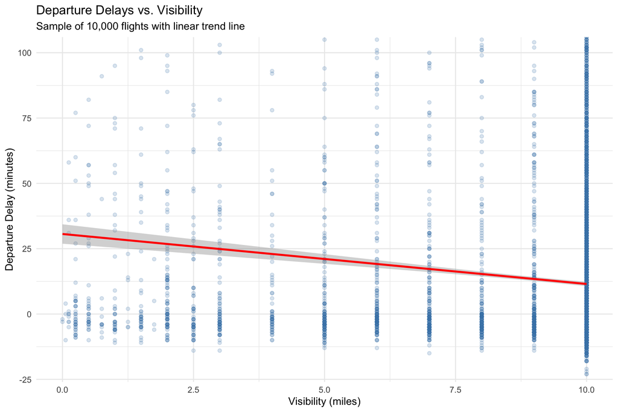

```r
# Scatterplot: visibility vs delays (sample for performance)
set.seed(42)
ggplot(flights_weather_clean |> sample_n(10000),
       aes(x = visib, y = dep_delay)) +
  geom_point(alpha = 0.2, color = "steelblue") +
  geom_smooth(method = "lm", color = "red", se = TRUE) +
  coord_cartesian(ylim = c(-20, 100)) +
  labs(
    title = "Departure Delays vs. Visibility",
    subtitle = "Sample of 10,000 flights with linear trend line",
    x = "Visibility (miles)",
    y = "Departure Delay (minutes)"
  ) +
  theme_minimal()
```

The scatter plot shows that lower visibility is associated with higher delays, though there is substantial variation.

## Conclusion

This analysis of the nycflights13 dataset reveals important relationships between weather conditions and flight delays:

### Key Findings

1. **Precipitation has the strongest practical impact:**
   - Heavy precipitation (>0.5 inches) results in average delays of ~49 minutes
   - This is more than 4× the average delay in dry conditions (~11 minutes)
   - Nearly 70% of flights are delayed during heavy precipitation
2. **Visibility matters:**
   - Very poor visibility (<1 mile) nearly triples average delays compared to clear conditions
   - The effect is substantial but less dramatic than precipitation
3. **Weather correlations are weak but consistent:**
   - Individual weather variables show weak correlations with delays (all <0.12)
   - However, categorical analysis reveals strong practical effects
   - This suggests weather interacts with other factors (aircraft cascading, crew scheduling, etc.)

### Practical Implications

- **For travelers**: Consider avoiding flights during periods of precipitation or poor visibility
- **For airlines**: Weather-related delays compound throughout the day, affecting multiple flights
- **For airports**: Investment in all-weather capabilities can significantly reduce delays

### Future Analysis

Potential extensions of this work could include:

- Seasonal patterns in weather-related delays
- Comparison of how different airports handle weather conditions
- Combined effects of multiple weather factors
- Impact of weather on arrival delays vs. departure delays
- Analysis of how delays propagate through the day

This analysis demonstrates that while weather is just one factor affecting flight delays, adverse conditions—particularly precipitation—have a clear and substantial impact on flight operations at New York City airports.